# 02-rmd-figures-chunks

Nicholas Tierney

2017/06/27

# Tasks

- Change the fig.width, fig.height, and dev of the figure in plot-1
- (hint: look at the gear icon in a chunk)
- Add an option to keep the markdown source code
- (hint: look at the gear icon next to `knit` icon)
- print the code for one of the figures, but not the other (hint: use `echo =`)

# Introduction

This is a simple analysis of the New York Air Quality Measurements using the R statistical programming language. As stated in the helpfile `?airquality`, this dataset contains:

> Daily air quality measurements in New York, May to September 1973.

And the dataset is sourced from:

> … the New York State Department of Conservation (ozone data) and the National Weather Service (meteorological data).

It contains the following variables

- Ozone: Mean ozone in parts per billion from 1300 to 1500 hours at Roosevelt Island.
- Solar.R: Solar radiation in Langleys in the frequency band 4000–7700 Angstroms from 0800 to 1200 hours at Central Park.
- Wind: Average wind speed in miles per hour at 0700 and 1000 hours at LaGuardia Airport.
- Temp: Maximum daily temperature in degrees Fahrenheit at La Guardia Airport.
- Month: Month (1–12)
- Day: Day of month (1–31)

We are going to explore the relationship between solar radiation and other selected variables, solar radiation, wind, and temperature.

# Results

We can see that there is an interesting relationship between ozone and solar radiation in figure 1 below, plotted using ggplot2.

[figure not shown]

We can also see that there is an interesting relationship between Ozone and temperature.

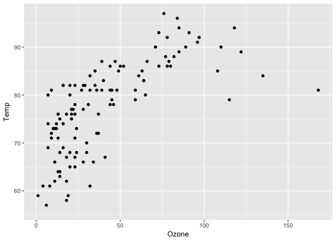

```r
ggplot(airquality,
       aes(x = Ozone,
           y = Temp)) +
  geom_point()
```